# RePsychLing Kliegl, Kuschela, & Laubrock (2015)- Reduction of Model Complexity

Author

Phillip Alday, Douglas Bates, and Reinhold Kliegl

Published

2024-09-13

# 1 Background

Kliegl et al. (2015) is a follow-up to Kliegl et al. (2011) (see also script `kwdyz11.qmd`) from an experiment looking at a variety of effects of visual cueing under four different cue-target relations (CTRs). In this experiment two rectangles are displayed (1) in horizontal orientation , (2) in vertical orientation, (3) in left diagonal orientation, or in (4) right diagonal orientation relative to a central fixation point. Subjects react to the onset of a small or a large visual target occurring at one of the four ends of the two rectangles. The target is cued validly on 70% of trials by a brief flash of the corner of the rectangle at which it appears; it is cued invalidly at the three other locations 10% of the trials each. This implies a latent imbalance in design that is not visible in the repeated-measures ANOVA, but we will show its effect in the random-effect structure and conditional modes.

There are a couple of differences between the first and this follow-up experiment, rendering it more a conceptual than a direct replication. First, the original experiment was carried out at Peking University and this follow-up at Potsdam University. Second, diagonal orientations of rectangles and large target sizes were not part of the design of Kliegl et al. (2011).

Here we also include two additional experimental manipulations of target size and orientation of cue rectangle. A similar analysis was reported in the parsimonious mixed-model paper (Bates et al., 2015); it was also used in a paper of GAMEMs (Baayen et al., 2017). Data and R scripts of those analyses are also available in [R-package RePsychLing](https://github.com/dmbates/RePsychLing/tree/master/data/).

The analysis is based on reaction times `rt` to maintain compatibility with Kliegl et al. (2011).

In this vignette we focus on the reduction of model complexity. And we start with a quote:

“Neither the [maximal] nor the [minimal] linear mixed models are appropriate for most repeated measures analysis. Using the [maximal] model is generally wasteful and costly in terms of statiscal power for testing hypotheses. On the other hand, the [minimal] model fails to account for nontrivial correlation among repeated measurements. This results in inflated [T]ype I error rates when non-negligible correlation does in fact exist. We can usually find middle ground, a covariance model that adequately accounts for correlation but is more parsimonious than the [maximal] model. Doing so allows us full control over [T]ype I error rates without needlessly sacrificing power.”

Stroup, W. W. (2012, p. 185). *Generalized linear mixed models: Modern concepts, methods and applica?ons.* CRC Press, Boca Raton.

# 2 Packages

```julia
using AlgebraOfGraphics
using AlgebraOfGraphics: density
using BoxCox
using CairoMakie
using CategoricalArrays
using Chain
using DataFrameMacros
using DataFrames
using MixedModels
using MixedModelsMakie
using Random
using SMLP2024: dataset
using StatsBase
```

# 3 Read data, compute and plot means

```julia
dat = DataFrame(dataset(:kkl15))
describe(dat)
```

5×7 DataFrame

| Row | variable Symbol | mean Union… | min Any | median Union… | max Any | nmissing Int64 | eltype DataType |
| --- | --- | --- | --- | --- | --- | --- | --- |
| 1 | Subj |  | S001 |  | S147 | 0 | String |
| 2 | CTR |  | dod |  | val | 0 | String |
| 3 | rt | 293.147 | 150.22 | 276.594 | 749.481 | 0 | Float32 |
| 4 | cardinal |  | cardinal |  | diagonal | 0 | String |
| 5 | size |  | big |  | small | 0 | String |

```julia
dat_subj = combine(
  groupby(dat, [:Subj, :CTR]),
  nrow => :n,
  :rt => mean => :rt_m,
  :rt => (c -> mean(log, c)) => :lrt_m,
)
dat_subj.CTR = categorical(dat_subj.CTR, levels=levels(dat.CTR))
describe(dat_subj)
```

5×7 DataFrame

| Row | variable Symbol | mean Union… | min Any | median Union… | max Any | nmissing Int64 | eltype DataType |
| --- | --- | --- | --- | --- | --- | --- | --- |
| 1 | Subj |  | S001 |  | S147 | 0 | String |
| 2 | CTR |  | val |  | dod | 0 | CategoricalValue{String, UInt32} |
| 3 | n | 156.294 | 49 | 64.0 | 448 | 0 | Int64 |
| 4 | rt_m | 308.223 | 208.194 | 304.862 | 584.71 | 0 | Float32 |
| 5 | lrt_m | 5.6908 | 5.33226 | 5.69848 | 6.36141 | 0 | Float32 |

```julia
boxplot(
  dat_subj.CTR.refs,
  dat_subj.lrt_m;
  orientation=:horizontal,
  show_notch=true,
  axis=(;
    yticks=(
      1:4,
      [
        "valid cue",
        "same obj/diff pos",
        "diff obj/same pos",
        "diff obj/diff pos",
      ]
    )
  ),
  figure=(; resolution=(800, 300)),
)
```

[output not shown]

[figure not shown]

Figure 1: Comparative boxplots of mean response time by subject under different conditions

Mean of reaction times for four cue-target relations. Targets appeared at (a) the cued position (valid) in a rectangle, (b) in the same rectangle cue, but at its other end, (c) on the second rectangle, but at a corresponding horizontal/vertical physical distance, or (d) at the other end of the second rectangle, that is $\sqrt{2}$ of horizontal/vertical distance diagonally across from the cue, that is also at larger physical distance compared to (c).

# 4 Contrasts

```julia
contrasts = Dict(
  :CTR => SeqDiffCoding(; levels=["val", "sod", "dos", "dod"]),
  :cardinal => EffectsCoding(; levels=["cardinal", "diagonal"]),
  :size => EffectsCoding(; levels=["big", "small"])
)
```

```
Dict{Symbol, StatsModels.AbstractContrasts} with 3 entries:
  :CTR      => SeqDiffCoding(["val", "sod", "dos", "dod"])
  :size     => EffectsCoding(nothing, ["big", "small"])
  :cardinal => EffectsCoding(nothing, ["cardinal", "diagonal"])
```

# 5 Maximum LMM

This is the maximum LMM for the design; `size` is a between-subject factor, ignoring other information such as trial number, age and gender of subjects.

```julia
m_max = let
  form = @formula rt ~ 1 + CTR * cardinal * size +
                           (1 + CTR * cardinal | Subj)
  fit(MixedModel, form, dat; contrasts)
end;
```

```
Minimizing 142    Time: 0:00:00 ( 0.70 ms/it)
  objective:  599458.051337806
Minimizing 876    Time: 0:00:00 ( 0.42 ms/it)

Minimizing 877    Time: 0:00:00 ( 0.44 ms/it)
  objective:  599358.9785788914
```

```julia
issingular(m_max)
```

```
true
```

```julia
only(MixedModels.PCA(m_max))
```

```
Principal components based on correlation matrix
 (Intercept)                     1.0   …    .      .      .      .      .
 CTR: sod                        0.6        .      .      .      .      .
 CTR: dos                        0.44       .      .      .      .      .
 CTR: dod                        0.38      1.0     .      .      .      .
 cardinal: diagonal             -0.03      0.15   1.0     .      .      .
 CTR: sod & cardinal: diagonal   0.32  …   0.02   0.26   1.0     .      .
 CTR: dos & cardinal: diagonal   0.42     -0.02   0.24   0.43   1.0     .
 CTR: dod & cardinal: diagonal   0.14      0.88   0.11   0.26   0.07   1.0

Normalized cumulative variances:
[0.3611, 0.5905, 0.7428, 0.8638, 0.9457, 1.0, 1.0, 1.0]

Component loadings
                                  PC1  …    PC4    PC5    PC6    PC7    PC8
 (Intercept)                    -0.43     -0.15  -0.29   0.47  -0.19   0.46
 CTR: sod                       -0.35     -0.41  -0.03  -0.23  -0.12  -0.59
 CTR: dos                       -0.39      0.35  -0.1   -0.75  -0.08   0.19
 CTR: dod                       -0.45      0.22  -0.18   0.1    0.7    0.06
 cardinal: diagonal             -0.12  …  -0.56  -0.48  -0.16  -0.13   0.1
 CTR: sod & cardinal: diagonal  -0.31     -0.43   0.72  -0.01   0.26   0.14
 CTR: dos & cardinal: diagonal  -0.24      0.22  -0.15   0.33   0.06  -0.6
 CTR: dod & cardinal: diagonal  -0.41      0.3    0.31   0.17  -0.6    0.0
```

```julia
VarCorr(m_max)
```

|  | Column | Variance | Std.Dev | Corr. |  |  |  |  |  |  |
| --- | --- | --- | --- | --- | --- | --- | --- | --- | --- | --- |
| Subj | (Intercept) | 2938.44786 | 54.20745 |  |  |  |  |  |  |  |
|  | CTR: sod | 455.44655 | 21.34119 | +0.60 |  |  |  |  |  |  |
|  | CTR: dos | 56.85753 | 7.54039 | +0.44 | +0.18 |  |  |  |  |  |
|  | CTR: dod | 192.63470 | 13.87929 | +0.38 | +0.54 | +0.30 |  |  |  |  |
|  | cardinal: diagonal | 261.91287 | 16.18372 | -0.03 | -0.01 | +0.00 | +0.15 |  |  |  |
|  | CTR: sod & cardinal: diagonal | 30.20533 | 5.49594 | +0.32 | +0.21 | +0.33 | +0.02 | +0.26 |  |  |
|  | CTR: dos & cardinal: diagonal | 1.64655 | 1.28318 | +0.42 | -0.37 | +0.58 | -0.02 | +0.24 | +0.43 |  |
|  | CTR: dod & cardinal: diagonal | 13.89368 | 3.72742 | +0.14 | +0.28 | +0.25 | +0.88 | +0.11 | +0.26 | +0.07 |
| Residual |  | 3972.11165 | 63.02469 |  |  |  |  |  |  |  |

The LMM `m_max` is overparameterized but it is not immediately apparent why.

# 6 Reduction strategy 1

## 6.1 Zero-correlation parameter LMM (1)

Force CPs to zero. *Reduction strategy 1* is more suited for reducing model w/o theoretical expectations about CPs. The better reduction strategy for the present experiment with an *a priori* interest in CPs is described as *Reduction strategy 2*.

```julia
m_zcp1 = let
  form = @formula rt ~ 1 + CTR * cardinal * size +
                   zerocorr(1 + CTR * cardinal | Subj)
  fit(MixedModel, form, dat; contrasts)
end;
```

```julia
issingular(m_zcp1)
```

```
true
```

```julia
only(MixedModels.PCA(m_zcp1))
```

```
Principal components based on correlation matrix
 (Intercept)                    1.0  .    .    .    .    .    .    .
 CTR: sod                       0.0  1.0  .    .    .    .    .    .
 CTR: dos                       0.0  0.0  1.0  .    .    .    .    .
 CTR: dod                       0.0  0.0  0.0  1.0  .    .    .    .
 cardinal: diagonal             0.0  0.0  0.0  0.0  1.0  .    .    .
 CTR: sod & cardinal: diagonal  0.0  0.0  0.0  0.0  0.0  1.0  .    .
 CTR: dos & cardinal: diagonal  0.0  0.0  0.0  0.0  0.0  0.0  0.0  .
 CTR: dod & cardinal: diagonal  0.0  0.0  0.0  0.0  0.0  0.0  0.0  1.0

Normalized cumulative variances:
[0.1429, 0.2857, 0.4286, 0.5714, 0.7143, 0.8571, 1.0, 1.0]

Component loadings
                                 PC1   PC2  …   PC4   PC5   PC6   PC7     PC8
 (Intercept)                    1.0   0.0      0.0   0.0   0.0   0.0     0.0
 CTR: sod                       0.0   1.0      0.0   0.0   0.0   0.0     0.0
 CTR: dos                       0.0   0.0      0.0   0.0   0.0   0.0     0.0
 CTR: dod                       0.0   0.0      1.0   0.0   0.0   0.0     0.0
 cardinal: diagonal             0.0   0.0   …  0.0   1.0   0.0   0.0     0.0
 CTR: sod & cardinal: diagonal  0.0   0.0      0.0   0.0   1.0   0.0     0.0
 CTR: dos & cardinal: diagonal  0.0   0.0      0.0   0.0   0.0   0.0   NaN
 CTR: dod & cardinal: diagonal  0.0   0.0      0.0   0.0   0.0   1.0     0.0
```

```julia
VarCorr(m_zcp1)
```

|  | Column | Variance | Std.Dev | Corr. |  |  |  |  |  |  |
| --- | --- | --- | --- | --- | --- | --- | --- | --- | --- | --- |
| Subj | (Intercept) | 2875.43244 | 53.62306 |  |  |  |  |  |  |  |
|  | CTR: sod | 483.09089 | 21.97933 | . |  |  |  |  |  |  |
|  | CTR: dos | 79.93243 | 8.94049 | . | . |  |  |  |  |  |
|  | CTR: dod | 216.91700 | 14.72810 | . | . | . |  |  |  |  |
|  | cardinal: diagonal | 250.32171 | 15.82156 | . | . | . | . |  |  |  |
|  | CTR: sod & cardinal: diagonal | 35.91784 | 5.99315 | . | . | . | . | . |  |  |
|  | CTR: dos & cardinal: diagonal | 0.00000 | 0.00000 | . | . | . | . | . | . |  |
|  | CTR: dod & cardinal: diagonal | 6.88389 | 2.62372 | . | . | . | . | . | . | . |
| Residual |  | 3972.38114 | 63.02683 |  |  |  |  |  |  |  |

The LMM `m_zcp1` is also overparameterized, but now there is clear evidence for absence of evidence for the VC of one of the interactions and the other two interaction-based VCs are also very small.

## 6.2 Reduced zcp LMM

Take out VCs for interactions.

```julia
m_zcp1_rdc = let
  form = @formula rt ~ 1 + CTR * cardinal * size +
                   zerocorr(1 + CTR + cardinal | Subj)
  fit(MixedModel, form, dat; contrasts)
end;
```

```julia
issingular(m_zcp1_rdc)
```

```
false
```

```julia
only(MixedModels.PCA(m_zcp1_rdc))
```

```
Principal components based on correlation matrix
 (Intercept)         1.0  .    .    .    .
 CTR: sod            0.0  1.0  .    .    .
 CTR: dos            0.0  0.0  1.0  .    .
 CTR: dod            0.0  0.0  0.0  1.0  .
 cardinal: diagonal  0.0  0.0  0.0  0.0  1.0

Normalized cumulative variances:
[0.2, 0.4, 0.6, 0.8, 1.0]

Component loadings
                      PC1   PC2   PC3   PC4   PC5
 (Intercept)         0.0   0.0   0.0   0.0   1.0
 CTR: sod            1.0   0.0   0.0   0.0   0.0
 CTR: dos            0.0   1.0   0.0   0.0   0.0
 CTR: dod            0.0   0.0   1.0   0.0   0.0
 cardinal: diagonal  0.0   0.0   0.0   1.0   0.0
```

```julia
VarCorr(m_zcp1_rdc)
```

|  | Column | Variance | Std.Dev | Corr. |  |  |  |
| --- | --- | --- | --- | --- | --- | --- | --- |
| Subj | (Intercept) | 2881.45052 | 53.67914 |  |  |  |  |
|  | CTR: sod | 484.31679 | 22.00720 | . |  |  |  |
|  | CTR: dos | 79.54961 | 8.91906 | . | . |  |  |
|  | CTR: dod | 216.59820 | 14.71728 | . | . | . |  |
|  | cardinal: diagonal | 244.93991 | 15.65056 | . | . | . | . |
| Residual |  | 3980.87777 | 63.09420 |  |  |  |  |

LMM `m_zcp_rdc` is ok . We add in CPs.

## 6.3 Parsimonious LMM (1)

Extend zcp-reduced LMM with CPs

```julia
m_prm1 = let
  form = @formula rt ~ 1 + CTR * cardinal * size +
                           (1 + CTR + cardinal | Subj)
  fit(MixedModel, form, dat; contrasts)
end;
```

```julia
issingular(m_prm1)
```

```
false
```

```julia
only(MixedModels.PCA(m_prm1))
```

```
Principal components based on correlation matrix
 (Intercept)          1.0     .      .      .      .
 CTR: sod             0.6    1.0     .      .      .
 CTR: dos             0.45   0.19   1.0     .      .
 CTR: dod             0.37   0.54   0.29   1.0     .
 cardinal: diagonal  -0.1   -0.05  -0.09   0.13   1.0

Normalized cumulative variances:
[0.4488, 0.6668, 0.8307, 0.9437, 1.0]

Component loadings
                       PC1    PC2    PC3    PC4    PC5
 (Intercept)         -0.55  -0.16   0.01   0.58  -0.58
 CTR: sod            -0.54   0.09  -0.49   0.17   0.66
 CTR: dos            -0.4   -0.25   0.8   -0.13   0.34
 CTR: dod            -0.49   0.36  -0.1   -0.71  -0.35
 cardinal: diagonal   0.05   0.88   0.32   0.34   0.07
```

```julia
VarCorr(m_prm1)
```

|  | Column | Variance | Std.Dev | Corr. |  |  |  |
| --- | --- | --- | --- | --- | --- | --- | --- |
| Subj | (Intercept) | 2926.39374 | 54.09615 |  |  |  |  |
|  | CTR: sod | 454.10921 | 21.30984 | +0.60 |  |  |  |
|  | CTR: dos | 56.75233 | 7.53341 | +0.45 | +0.19 |  |  |
|  | CTR: dod | 188.74621 | 13.73849 | +0.37 | +0.54 | +0.29 |  |
|  | cardinal: diagonal | 245.27143 | 15.66114 | -0.10 | -0.05 | -0.09 | +0.13 |
| Residual |  | 3981.71306 | 63.10082 |  |  |  |  |

We note that the critical correlation parameter between spatial (`sod`) and attraction (`dod`) is now estimated at .54 – not that close to the 1.0 boundary that caused singularity in Kliegl et al. (2011).

## 6.4 Model comparison 1

```julia
gof_summary = let
  nms = [:m_zcp1_rdc, :m_prm1, :m_max]
  mods = eval.(nms)
  lrt = MixedModels.likelihoodratiotest(m_zcp1_rdc, m_prm1, m_max)
  DataFrame(;
    name = nms,
    dof=dof.(mods),
    deviance=round.(deviance.(mods), digits=0),
    AIC=round.(aic.(mods),digits=0),
    AICc=round.(aicc.(mods),digits=0),
     BIC=round.(bic.(mods),digits=0),
    χ²=vcat(:., round.(lrt.tests.deviancediff, digits=0)),
    χ²_dof=vcat(:., round.(lrt.tests.dofdiff, digits=0)),
    pvalue=vcat(:., round.(lrt.tests.pvalues, digits=3))
  )
end
```

3×9 DataFrame

| Row | name Symbol | dof Int64 | deviance Float64 | AIC Float64 | AICc Float64 | BIC Float64 | χ² Any | χ²_dof Any | pvalue Any |
| --- | --- | --- | --- | --- | --- | --- | --- | --- | --- |
| 1 | m_zcp1_rdc | 22 | 599486.0 | 599530.0 | 599530.0 | 599725.0 | . | . | . |
| 2 | m_prm1 | 32 | 599418.0 | 599482.0 | 599482.0 | 599766.0 | 68.0 | 10.0 | 0.0 |
| 3 | m_max | 53 | 599359.0 | 599465.0 | 599465.0 | 599936.0 | 59.0 | 21.0 | 0.0 |

AIC prefers LMM `m_prm1` over `m_zcp1_rdc`; BIC LMM `m_zcp1_rdc`. As the CPs were one reason for conducting this experiment, AIC is the criterion of choice.

# 7 Reduction strategy 2

## 7.1 Complex LMM

Relative to LMM `m_max`, first we take out interaction VCs and associated CPs, because these VCs are very small. This is the same as LMM `m_prm1` above.

```julia
m_cpx = let
  form = @formula rt ~ 1 + CTR * cardinal * size +
                      (1 + CTR + cardinal | Subj)
  fit(MixedModel, form, dat; contrasts)
end;
```

## 7.2 Zero-correlation parameter LMM (2)

Now we check the significance of ensemble of CPs.

```julia
m_zcp2 = let
  form = @formula rt ~ 1 + CTR * cardinal * size  +
              zerocorr(1 + CTR + cardinal | Subj)
  fit(MixedModel, form, dat; contrasts)
end;
```

```julia
VarCorr(m_zcp2)
```

|  | Column | Variance | Std.Dev | Corr. |  |  |  |
| --- | --- | --- | --- | --- | --- | --- | --- |
| Subj | (Intercept) | 2881.45052 | 53.67914 |  |  |  |  |
|  | CTR: sod | 484.31679 | 22.00720 | . |  |  |  |
|  | CTR: dos | 79.54961 | 8.91906 | . | . |  |  |
|  | CTR: dod | 216.59820 | 14.71728 | . | . | . |  |
|  | cardinal: diagonal | 244.93991 | 15.65056 | . | . | . | . |
| Residual |  | 3980.87777 | 63.09420 |  |  |  |  |

## 7.3 Parsimonious LMM (2)

The cardinal-related CPs are quite small. Do we need them?

```julia
m_prm2 = let
  form = @formula(rt ~ 1 + CTR * cardinal * size  +
                      (1 + CTR | Subj) + (0 + cardinal | Subj))
  fit(MixedModel, form, dat; contrasts)
end;
```

```julia
VarCorr(m_prm2)
```

|  | Column | Variance | Std.Dev | Corr. |  |  |  |
| --- | --- | --- | --- | --- | --- | --- | --- |
| Subj | (Intercept) | 2923.32186 | 54.06775 |  |  |  |  |
|  | CTR: sod | 454.38842 | 21.31639 | +0.60 |  |  |  |
|  | CTR: dos | 56.46065 | 7.51403 | +0.45 | +0.19 |  |  |
|  | CTR: dod | 187.89792 | 13.70759 | +0.37 | +0.54 | +0.30 |  |
|  | cardinal: diagonal | 245.16943 | 15.65789 | . | . | . | . |
| Residual |  | 3981.74285 | 63.10105 |  |  |  |  |

## 7.4 Model comparison 2

```julia
gof_summary = let
  nms = [:m_zcp2, :m_prm2, :m_cpx, :m_max]
  mods = eval.(nms)
  lrt = MixedModels.likelihoodratiotest(m_zcp2, m_prm2, m_cpx, m_max)
  DataFrame(;
    name = nms,
    dof=dof.(mods),
    deviance=round.(deviance.(mods), digits=0),
    AIC=round.(aic.(mods),digits=0),
    AICc=round.(aicc.(mods),digits=0),
     BIC=round.(bic.(mods),digits=0),
    χ²=vcat(:., round.(lrt.tests.deviancediff, digits=0)),
    χ²_dof=vcat(:., round.(lrt.tests.dofdiff, digits=0)),
    pvalue=vcat(:., round.(lrt.tests.pvalues, digits=3))
  )
end
```

4×9 DataFrame

| Row | name Symbol | dof Int64 | deviance Float64 | AIC Float64 | AICc Float64 | BIC Float64 | χ² Any | χ²_dof Any | pvalue Any |
| --- | --- | --- | --- | --- | --- | --- | --- | --- | --- |
| 1 | m_zcp2 | 22 | 599486.0 | 599530.0 | 599530.0 | 599725.0 | . | . | . |
| 2 | m_prm2 | 28 | 599420.0 | 599476.0 | 599476.0 | 599725.0 | 65.0 | 6.0 | 0.0 |
| 3 | m_cpx | 32 | 599418.0 | 599482.0 | 599482.0 | 599766.0 | 2.0 | 4.0 | 0.652 |
| 4 | m_max | 53 | 599359.0 | 599465.0 | 599465.0 | 599936.0 | 59.0 | 21.0 | 0.0 |

The cardinal-related CPs could be removed w/o loss of goodness of fit. However, there is no harm in keeping them in the LMM. The data support both LMM `m_prm2` and `m_cpx` (same as: `m_prm1`). We keep the slightly more complex LMM `m_cpx` (`m_prm1`).

# 8 Diagnostic plots of LMM residuals

Do model residuals meet LMM assumptions? Classic plots are

- Residual over fitted
- Quantiles of model residuals over theoretical quantiles of normal distribution

## 8.1 Residual-over-fitted plot

The slant in residuals show a lower and upper boundary of reaction times, that is we have have too few short and too few long residuals. Not ideal, but at least width of the residual band looks similar across the fitted values, that is there is no evidence for heteroskedasticity.

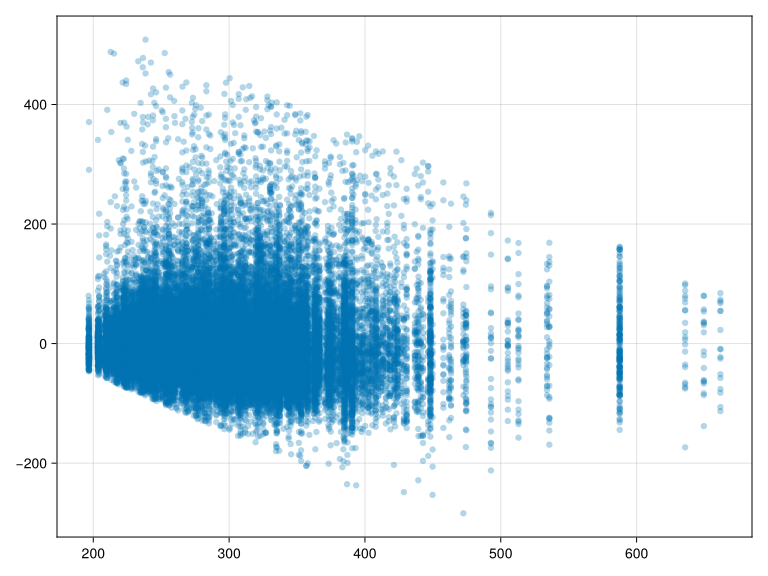

Figure 2: Residuals versus fitted values for model m1

```julia
CairoMakie.activate!(; type="png")
scatter(fitted(m_prm1), residuals(m_prm1); alpha=0.3)
```

With many observations the scatterplot is not that informative. Contour plots or heatmaps may be an alternative.

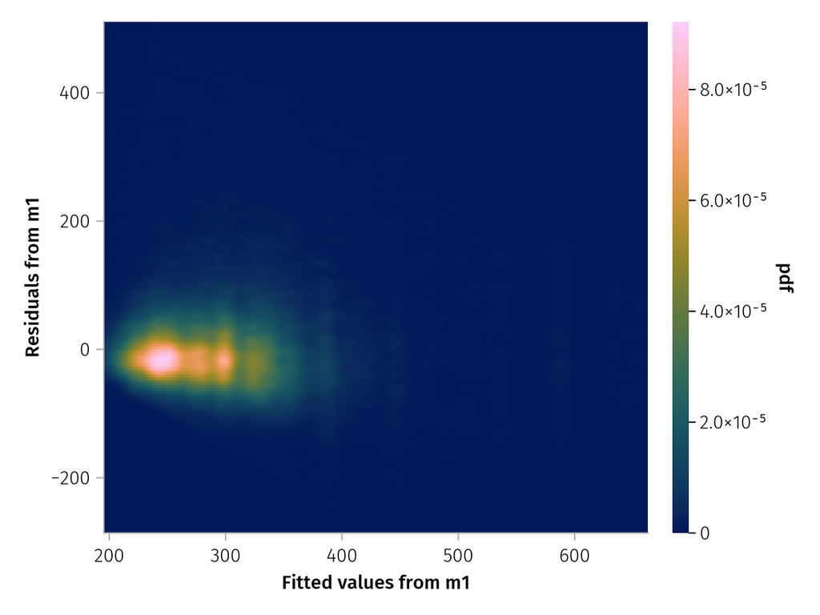

Figure 3: Heatmap of residuals versus fitted values for model m1

```julia
set_aog_theme!()
draw(
  data((; f=fitted(m_prm1), r=residuals(m_prm1))) *
  mapping(
    :f => "Fitted values from m1", :r => "Residuals from m1"
  ) *
  density();
)
```

## 8.2 Q-Q plot

The plot of quantiles of model residuals over corresponding quantiles of the normal distribution should yield a straight line along the main diagonal.

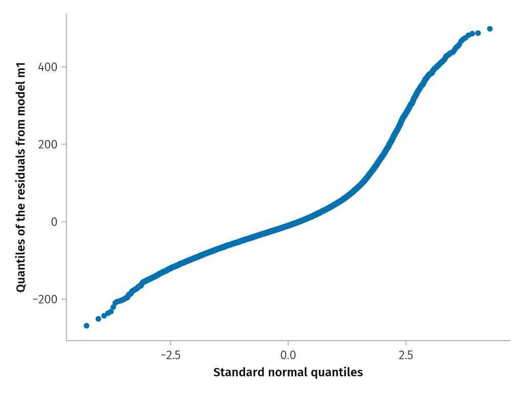

Figure 4: Quantile-quantile plot of the residuals for model m1 versus a standard normal

```julia
CairoMakie.activate!(; type="png")
qqnorm(
  residuals(m_prm1);
  qqline=:none,
  axis=(;
    xlabel="Standard normal quantiles",
    ylabel="Quantiles of the residuals from model m1",
  ),
)
```

# 9 Conditional modes

## 9.1 Caterpillar plot

[output not shown]

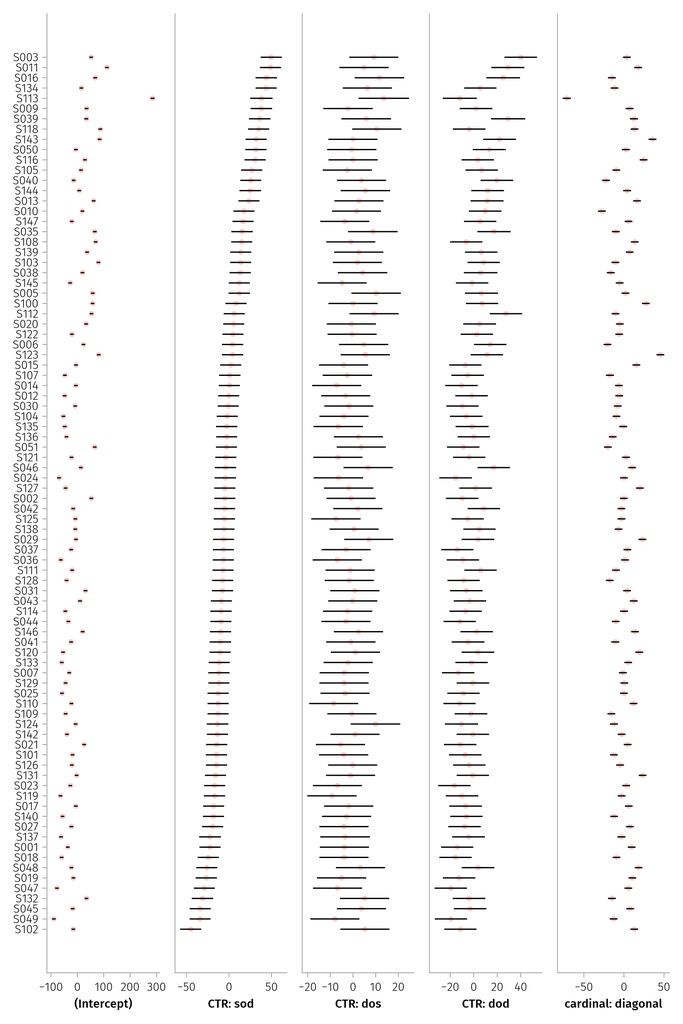

Figure 5: Prediction intervals of the subject random effects in model m1

```julia
cm1 = only(ranefinfo(m_prm1))
caterpillar!(Figure(; resolution=(800, 1200)), cm1; orderby=2)
```

## 9.2 Shrinkage plot

[output not shown]

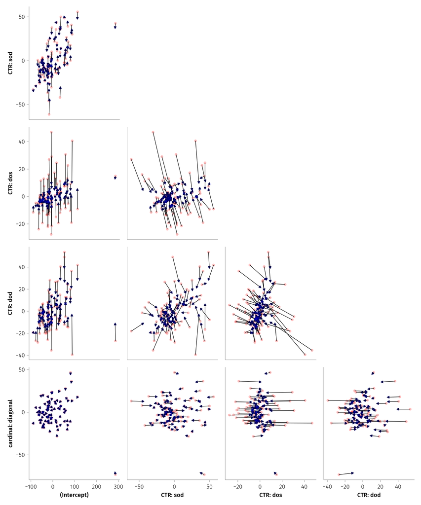

Figure 6: Shrinkage plots of the subject random effects in model m1L

```julia
shrinkageplot!(Figure(; resolution=(1000, 1200)), m_prm1)
```

# 10 Parametric bootstrap

Here we

- generate a bootstrap sample
- compute shortest covergage intervals for the LMM parameters
- plot densities of bootstrapped parameter estimates for residual, fixed effects, variance components, and correlation parameters

## 10.1 Generate a bootstrap sample

```julia
samp = parametricbootstrap(MersenneTwister(1234321), 2500, m_prm1;
                           optsum_overrides=(; ftol_rel=1e-8));
```

```julia
tbl = samp.tbl
```

```
Table with 48 columns and 2500 rows:
      obj        β01      β02      β03      β04       β05      β06      ⋯
    ┌────────────────────────────────────────────────────────────────────
 1  │ 5.98897e5  301.101  22.1122  11.2895  0.876659  5.29574  20.7015  ⋯
 2  │ 5.9964e5   314.198  23.9774  13.0657  3.54125   6.27177  26.0213  ⋯
 3  │ 5.99601e5  313.482  25.8522  12.6864  2.6665    5.99473  26.2079  ⋯
 4  │ 5.99422e5  307.342  21.8929  14.5687  5.14975   6.46233  21.4816  ⋯
 5  │ 5.9891e5   303.107  22.0525  13.8717  1.22361   9.06571  27.3694  ⋯
 6  │ 5.99241e5  304.327  20.6646  12.9426  3.01194   5.19863  31.4934  ⋯
 7  │ 599535.0   315.078  26.3107  13.0825  6.77259   6.14113  18.2759  ⋯
 8  │ 5.99182e5  306.15   23.4631  12.4967  4.0268    6.32004  27.5211  ⋯
 9  │ 6.0014e5   304.214  22.5889  10.4741  3.78498   6.67903  23.2066  ⋯
 10 │ 5.994e5    307.004  25.5547  14.8672  1.09287   3.08337  18.9497  ⋯
 11 │ 5.98984e5  302.778  20.5811  12.5438  3.28193   7.46265  28.1793  ⋯
 12 │ 5.99649e5  313.379  26.6914  10.9561  1.26339   4.65612  32.3437  ⋯
 13 │ 5.99031e5  304.034  22.6971  12.175   2.1841    7.84183  36.4001  ⋯
 14 │ 5.9947e5   309.43   22.6176  15.1642  -0.58606  3.62731  32.418   ⋯
 15 │ 5.99092e5  319.095  24.0423  14.1444  5.27404   8.75307  29.1921  ⋯
 16 │ 5.99633e5  310.267  22.907   15.5719  3.72037   8.71994  25.3559  ⋯
 17 │ 5.99831e5  307.412  21.8683  13.7834  2.23826   9.10737  30.2628  ⋯
 ⋮  │     ⋮         ⋮        ⋮        ⋮        ⋮         ⋮        ⋮     ⋱
```

## 10.2 Shortest coverage interval

```julia
confint(samp)
```

```
DictTable with 2 columns and 32 rows:
 par   lower      upper
 ────┬────────────────────
 β01 │ 296.443    318.781
 β02 │ 18.3734    27.7957
 β03 │ 10.3257    16.0712
 β04 │ -1.18121   6.18787
 β05 │ 3.44619    10.2913
 β06 │ 14.9788    37.9644
 β07 │ 1.80928    5.35864
 β08 │ -0.998456  3.73246
 β09 │ -2.53041   2.20858
 β10 │ 3.72405    13.3908
 β11 │ -3.54059   2.37317
 β12 │ 3.72117    11.1719
 β13 │ -1.5557    5.11338
 β14 │ -2.46016   1.04481
 β15 │ -2.68508   2.1626
 β16 │ 1.70393    6.52866
 ρ01 │ 0.336762   0.792209
  ⋮  │     ⋮         ⋮
```

We can also visualize the shortest coverage intervals for fixed effects with the `ridgeplot()` command:

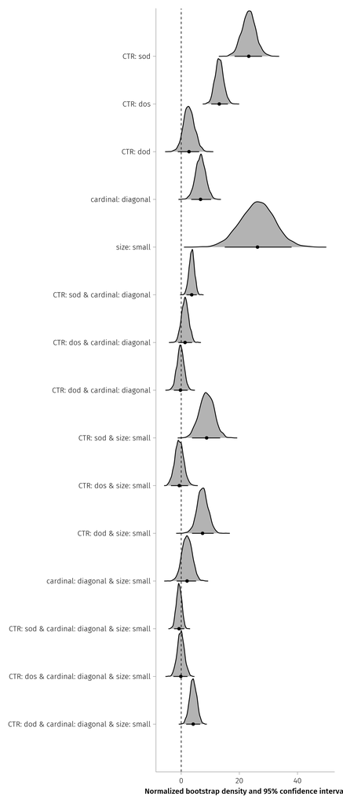

Figure 7: Ridge plot of fixed-effects bootstrap samples from model m1L

```julia
ridgeplot(samp; show_intercept=false)
```

## 10.3 Comparative density plots of bootstrapped parameter estimates

### 10.3.1 Residual

[output not shown]

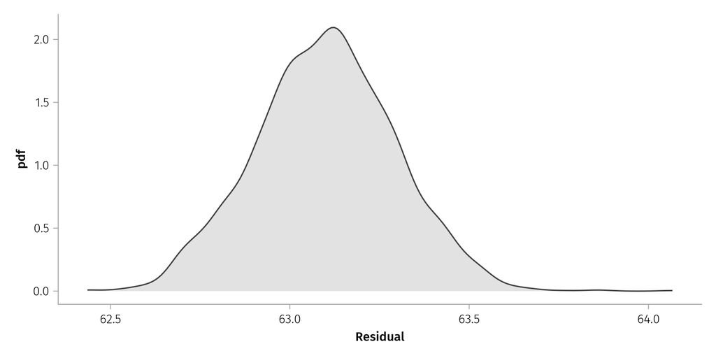

Figure 8: Kernel density estimate from bootstrap samples of the residual standard deviation for model m_prm1

```julia
draw(
  data(tbl) *
  mapping(:σ => "Residual") *
  density();
  figure=(; resolution=(800, 400)),
)
```

### 10.3.2 Fixed effects and associated variance components (w/o GM)

[output not shown]

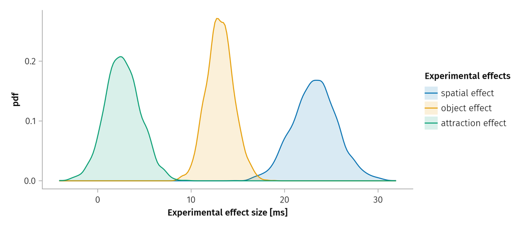

Figure 9: Kernel density estimate from bootstrap samples of the fixed effects for model m_prm1

```julia
rn = renamer([
  "(Intercept)" => "GM",
  "CTR: sod" => "spatial effect",
  "CTR: dos" => "object effect",
  "CTR: dod" => "attraction effect",
  "(Intercept), CTR: sod" => "GM, spatial",
  "(Intercept), CTR: dos" => "GM, object",
  "CTR: sod, CTR: dos" => "spatial, object",
  "(Intercept), CTR: dod" => "GM, attraction",
  "CTR: sod, CTR: dod" => "spatial, attraction",
  "CTR: dos, CTR: dod" => "object, attraction",
])
draw(
  data(tbl) *
  mapping(
    [:β02, :β03, :β04] .=> "Experimental effect size [ms]";
    color=dims(1) =>
    renamer(["spatial effect", "object effect", "attraction effect"]) =>
    "Experimental effects",
  ) *
  density();
  figure=(; resolution=(800, 350)),
)
```

The densitiies correspond nicely with the shortest coverage intervals.

[output not shown]

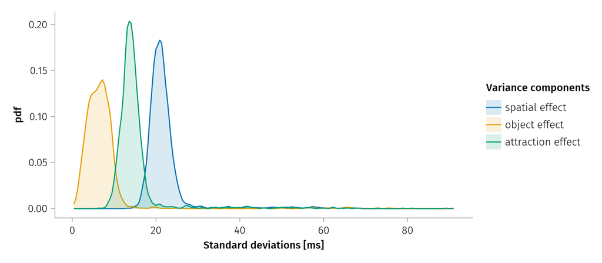

Figure 10: Kernel density estimate from bootstrap samples of the standard deviations for model m1L (excluding Grand Mean)

```julia
draw(
  data(tbl) *
  mapping(
    [:σ2, :σ3, :σ4] .=> "Standard deviations [ms]";
    color=dims(1) =>
    renamer(["spatial effect", "object effect", "attraction effect"]) =>
    "Variance components",
  ) *
  density();
  figure=(; resolution=(800, 350)),
)
```

The VC are all very nicely defined.

### 10.3.3 Correlation parameters (CPs)

[output not shown]

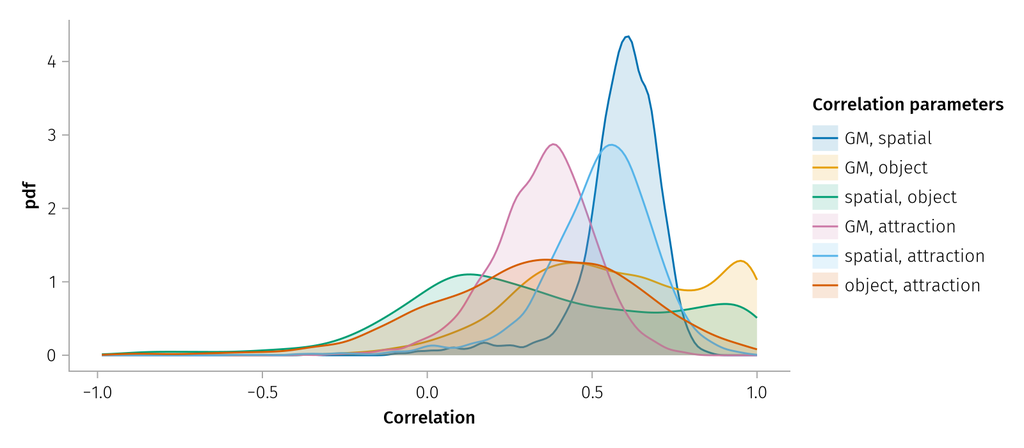

```julia
draw(
  data(tbl) *
  mapping(
    [:ρ01, :ρ02, :ρ03, :ρ04, :ρ05, :ρ06] .=> "Correlation";
    color=dims(1) =>
    renamer(["GM, spatial", "GM, object", "spatial, object",
    "GM, attraction", "spatial, attraction", "object, attraction"]) =>
    "Correlation parameters",
  ) *
  density();
  figure=(; resolution=(800, 350)),
)
```

Three CPs stand out positively, the correlation between GM and the spatial effect, GM and attraction effect, and the correlation between spatial and attraction effects. The second CP was positive, but not significant in the first study. The third CP replicates a CP that was judged questionable in script `kwdyz11.jl`. The three remaining CPs are not well defined for reaction times.

# 11 References

Baayen, H., Vasishth, S., Kliegl, R., & Bates, D. (2017). The cave of shadows: Addressing the human factor with generalized additive mixed models. *Journal of Memory and Language*, *94*, 206–234. https://doi.org/10.1016/j.jml.2016.11.006

Bates, D., Kliegl, R., Vasishth, S., & Baayen, H. (2015). *Parsimonious mixed models*. arXiv. https://doi.org/10.48550/ARXIV.1506.04967

Kliegl, R., Kushela, J., & Laubrock, J. (2015). *Object orientation and target size modulate the speed of visual attention*. Department of Psychology, University of Potsdam.

Kliegl, R., Wei, P., Dambacher, M., Yan, M., & Zhou, X. (2011). Experimental effects and individual differences in linear mixed models: Estimating the relationship between spatial, object, and attraction effects in visual attention. *Frontiers in Psychology*. https://doi.org/10.3389/fpsyg.2010.00238

Back to top